# MIDTERM PROJECT

Andrew Sisitzky,Chen Xu,Guangze Yu,Yuyang Li

20201 November 1

**DATA WRANGLING**

## Data clean-Strawberries.csv

- Take apart strawberries.csv and restructure,
- Use **Year, State, Domain, Chemical, Chemical type, Value, units** as variable to get a new table
- Select data when **Domain = “CHEMICAL”**

## Data clean-Strawberries.csv

- Empty rows were removed to make the data more compact
- The name of various pesticides were converted to uppercase letters for later matching

## Data wrangling-left_join

- Function *left_join* is used to match the data by **“chemicaltype = pesticide”**
- Combine them into one table for subsequent EDA
- Delete the missing value if **“Year = NA”**

**MAKE JUDGEMENTS**

## Give a number for toxins

- **For human**
  - Carcinogen:*known=4,probable=3,possible=2,unknown=1*
  - Hormone.Disruptor:*suspected=2,unknown=1*
  - Neurotoxins:*present=2,unknown=1*
  - Developmental/ReproductiveToxins:*present=2,unknown=1*
- **For bee**
  - Bee.Toxins:*high=4,moderate=3,slight=2,unknown=1*

## Calculate total toxins

- **For human**
  - Toxicity for human = *Carcinogen+HormoneDisruptor+Neurotoxins+ Developmental or Reproductive Toxins*
- **For bee**
  - Toxicity for bee = *Bee.Toxins*

**EDA**

## Choose data to plot

- Select chemical types exist in **Pesticides.csv**
- Filter dataframe into subsets in different measurements
  - MEASURED IN LB / ACRE / YEAR AVG
  - MEASURED IN PCT OF AREA BEARING AVG
  - MEASURED IN LB
  - MEASURED IN LB / ACRE / APPLICATION AVG
  - MEASURED IN NUMBER AVG

## EDA PLOT 1

- Looking at the average lbs of strawberries harvested per acre in each state.Added color to show the toxicity level of each observation.
- It appears that the harvests with higher lbs per acre also tend to be treated with chemicals that are rated higher by out **‘toxicitylevelhuman’** variable.

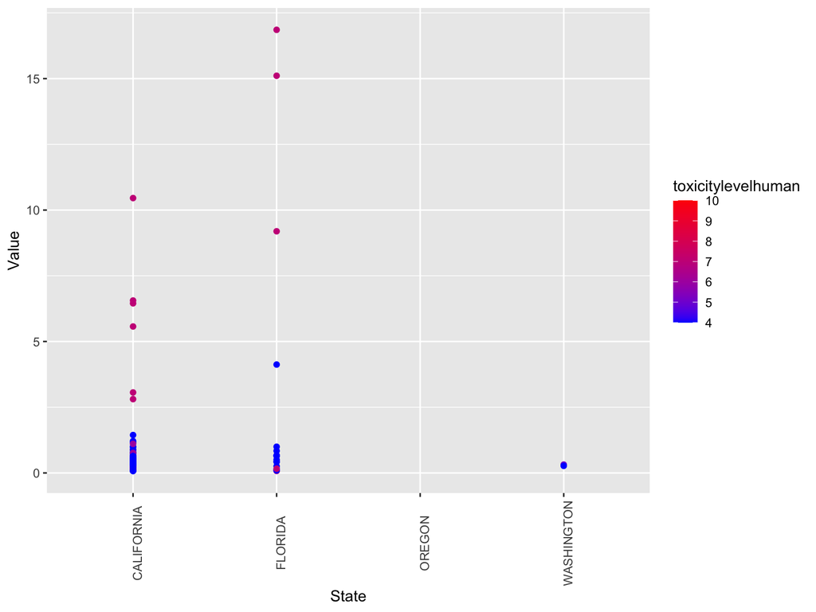

```r
edaplot <- ggplot(data=chemical_clean_lbperacre,mapping=aes(x=State,y=Value))+geom_point(mapping=aes(color=toxicitylevelhuman))+scale_color_gradient(low="blue", high="red")+theme(axis.text.x = element_text(angle = 90))
edaplot
```

## EDA Plot 2

- Adding the **mean toxicity** of all observations in each state to the map.
- This plot shows that, based on this dataset, the harvests in Oregon tended to use chemicals that were rated higher by our toxicity scale in comparison to other states.

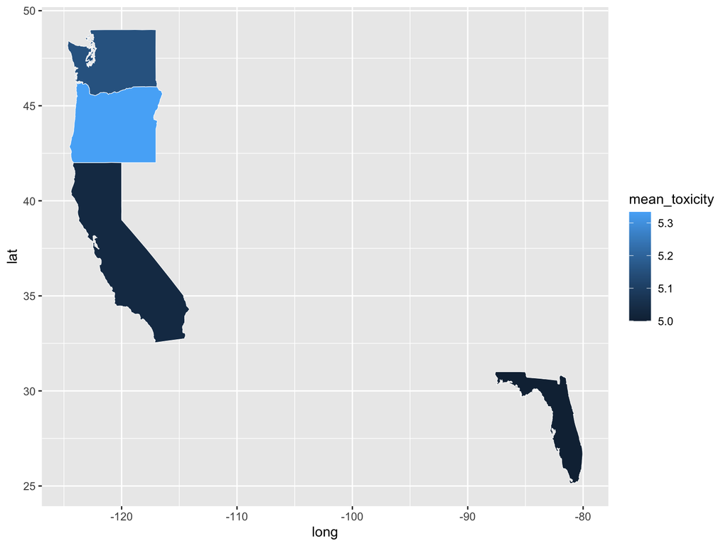

```r
edaplot2 <- ggplot() +geom_polygon( data=eda_subset, aes(x=long, y=lat, group=group,fill = mean_toxicity), color="white",size = 0.2)
edaplot2
```